# Analysis of Processing Power over Time

Dalton Pang, Sathwik Yanamadi, Timothy Lee

```python
import requests
import numpy as np
import pandas as pd
from bs4 import BeautifulSoup
import time
import re
```

# Introduction

A Central Processing Unit (CPU) is the heart of the computer that performs many processing functions for the system. CPUs are built by placing billions of microscopic transistors onto a single computer chip. Those transistors allow it to make the calculations it needs to run programs that are stored on your system’s memory. CPUs can also have multiple cores, which recieve instructions and perform operations to satisy those instructions. One of the most common advancements of CPU technology is in making those transistors smaller and increasing the number of cores. This has resulted in the steady improvement to CPU speed over the decades, often referred to as Moore’s Law.

The importance and value of advancing CPUs introduces great competition in the field of CPU development. In this project, we analyze the progression of CPU processing power in regards to its price to performance ratio, whether it is above or below the expected performance compared to the prediction of Moore's law, and the average marketshare of each competitor in relation to the strength of their products.

# Getting CPU and GPU Data

Source: https://www.techpowerup.com/cpu-specs/

```python
def getdata(url,kind):
    if kind=='cpu':
        columns=['Name','Codename','Cores','Clock','Socket','Process','L3 Cache','TDP','Released']
    elif kind=='gpu':
        columns=['Product Name','GPU Chip','Release Date','Bus','Memory','GPU Clock','Memory Clock','Shaders/TMUs/ROPs']

    df=pd.DataFrame()
    rest='&sort=released'
    r=requests.get(url+str(2000)+rest)
    root = BeautifulSoup(r.text, 'html')
    table = root.find_all("table")

    if kind=='cpu':
        other=pd.read_html(str(table))[0]
    elif kind=='gpu':
        other=pd.read_html(str(table[1]))[0]

    df=other
    if kind=='cpu':
        df = df.iloc[: , :-1]
    df = df.set_axis(columns, axis=1)

    years=[]
    for i in range(2001,2023):
        r=requests.get(url+str(i)+rest)
        root = BeautifulSoup(r.text, 'html')
        table = root.find_all("table")

        if kind=='cpu':
            other = pd.read_html(str(table))[0]
        elif kind=='gpu':
            other=pd.read_html(str(table[1]))[0]

        if kind=='cpu':
            other = other.iloc[: , :-1]
        other = other.set_axis(columns, axis=1)
        df=pd.concat([df,other])
        time.sleep(5)
    return df
```

```python
cpu_url='https://www.techpowerup.com/cpu-specs/?released='
cpudata=getdata(cpu_url,'cpu')
```

To avoid requesting the data from the website every time we need to run our code again, we just stored the data into a CSV file and loaded up the CSV file which is much quicker.

```python
compression_opts = dict(method='zip',
                        archive_name='CPUs.csv')
cpudata.to_csv('CPUs.zip', index=False,
          compression=compression_opts)
```

```python
cpu_df=pd.read_csv("CPUs.csv")
```

Printing out the dataframe below

```python
cpu_df
```

|  | Name | Codename | Cores | Clock | Socket | Process | L3 Cache | TDP | Released |
| --- | --- | --- | --- | --- | --- | --- | --- | --- | --- |
| 0 | Athlon 1000 | Thunderbird C | 1 | 1000 MHz | Socket A | 180 nm | NaN | 54 W | Oct 31st, 2000 |
| 1 | Athlon 1133 | Thunderbird C | 1 | 1133 MHz | Socket A | 180 nm | NaN | 63 W | Oct 31st, 2000 |
| 2 | Athlon 1200 | Thunderbird C | 1 | 1200 MHz | Socket A | 180 nm | NaN | 66 W | Oct 31st, 2000 |
| 3 | Athlon 1200 | Thunderbird B | 1 | 1200 MHz | Socket A | 180 nm | NaN | 66 W | Oct 17th, 2000 |
| 4 | Athlon 1100 | Thunderbird B | 1 | 1100 MHz | Socket A | 180 nm | NaN | 60 W | Aug 14th, 2000 |
| ... | ... | ... | ... | ... | ... | ... | ... | ... | ... |
| 2018 | Core i9-12900TE | Alder Lake-S | 16 / 24 | 1.1 to 4.8 GHz | Socket 1700 | 10 nm | 30MB | 35 W | Jan 4th, 2022 |
| 2019 | Pentium Gold G7400 | Alder Lake-S | 2 / 4 | 3.7 GHz | Socket 1700 | 10 nm | 6MB | 46 W | Jan 4th, 2022 |
| 2020 | Pentium Gold G7400E | Alder Lake-S | 2 / 4 | 3.6 GHz | Socket 1700 | 10 nm | 6MB | 46 W | Jan 4th, 2022 |
| 2021 | Pentium Gold G7400T | Alder Lake-S | 2 / 4 | 3.1 GHz | Socket 1700 | 10 nm | 6MB | 35 W | Jan 4th, 2022 |
| 2022 | Pentium Gold G7400TE | Alder Lake-S | 2 / 4 | 3 GHz | Socket 1700 | 10 nm | 6MB | 35 W | Jan 4th, 2022 |

2023 rows × 9 columns

## Adding Performance Measurements to the Data

We then got performance data for each of the CPUs from CPUBenchmark.net. These performance numbers are from benchmarks ran by CPUBenchmark that executes complex mathematical calcuations involving compression, encryption, and physics simulations. The higher the performance number the faster the CPU is. Once again, we created a dataframe with the columns we wanted and used BeautifulSoup to parse through the webpages HTML. Unforunately, the data was not in a table this time so we had to split up the unordered list it was in by line and remove any extra blank rows. We also used the chain module to flatten our data into a one-dimensional array. We then merged the two dataframes into one by using a library function that matched the names of one dataframe to the closesnt match in the other.

Source for CPU performance data: https://www.cpubenchmark.net/

```python
from itertools import chain

columnNames=['Name','Percentage','Performance','Price']
df2=pd.DataFrame(columns = columnNames)
url= "https://www.cpubenchmark.net/"
types = ["high_end_cpus", "mid_range_cpus", "midlow_range_cpus", "low_end_cpus"]
# types = ["high_end_cpus"]
data_list = []

for cpu_type in types:
    r=requests.get(url + str(cpu_type) + ".html")
    root = BeautifulSoup(r.text, 'html')
    root.prettify() # up to here is just getting all the html

    table = root.find_all("ul") # this gets all the unordered lists on the page
    table = table[12] # The 13th unordered list which is the main table
    table = str(table.text)
    data_list.append(table.split("\n")[1:-1])

flatten_list = list(chain.from_iterable(data_list))
```

```python
import difflib

names=[]
percentage=[]
performance=[]
price=[]
for item in flatten_list:
    result = re.search(r"((.)+)(\(\d+%\))([\d|,]+)(\$[\d|.|,]+|NA)", item)
    names.append(result.group(1))
    percentage.append(result.group(3))
    performance.append(result.group(4))
    price.append(result.group(5))
df2['Name']=names
df2['Percentage']=percentage
df2['Performance']=performance
df2['Price']=price

df2['Name'] = df2['Name'].apply(lambda x: (difflib.get_close_matches(x, cpu_df['Name'])[:1] or [None])[0])
cpu_df = cpu_df.merge(df2)
cpu_df
```

|  | Name | Codename | Cores | Clock | Socket | Process | L3 Cache | TDP | Released | Percentage | Performance | Price |
| --- | --- | --- | --- | --- | --- | --- | --- | --- | --- | --- | --- | --- |
| 0 | Athlon 1200 | Thunderbird C | 1 | 1200 MHz | Socket A | 180 nm | NaN | 66 W | Oct 31st, 2000 | (25%) | 272 | NA |
| 1 | Athlon 1200 | Thunderbird B | 1 | 1200 MHz | Socket A | 180 nm | NaN | 66 W | Oct 17th, 2000 | (25%) | 272 | NA |
| 2 | Athlon 1100 | Thunderbird B | 1 | 1100 MHz | Socket A | 180 nm | NaN | 60 W | Aug 14th, 2000 | (18%) | 197 | NA |
| 3 | Athlon 650 | Thunderbird | 1 | 650 MHz | Socket A | 180 nm | NaN | 38 W | Jun 5th, 2000 | (31%) | 338 | NA |
| 4 | Athlon 650 | Thunderbird | 1 | 650 MHz | Socket A | 180 nm | NaN | 38 W | Jun 5th, 2000 | (25%) | 274 | $19.00 |
| ... | ... | ... | ... | ... | ... | ... | ... | ... | ... | ... | ... | ... |
| 2463 | Core i9-12900HK | Alder Lake-H | 14 / 20 | 2.5 to 5 GHz | BGA 1744 | 10 nm | 24MB | 45 W | Jan 4th, 2022 | (23%) | 29,205 | $635.00 |
| 2464 | Core i9-12900T | Alder Lake-S | 16 / 24 | 1.4 to 4.9 GHz | Socket 1700 | 10 nm | 30MB | 35 W | Jan 4th, 2022 | (27%) | 35,007 | $489.00 |
| 2465 | Core i9-12900TE | Alder Lake-S | 16 / 24 | 1.1 to 4.8 GHz | Socket 1700 | 10 nm | 30MB | 35 W | Jan 4th, 2022 | (14%) | 17,888 | $444.00 |
| 2466 | Pentium Gold G7400 | Alder Lake-S | 2 / 4 | 3.7 GHz | Socket 1700 | 10 nm | 6MB | 46 W | Jan 4th, 2022 | (5%) | 6,912 | $86.99 |
| 2467 | Pentium Gold G7400 | Alder Lake-S | 2 / 4 | 3.7 GHz | Socket 1700 | 10 nm | 6MB | 46 W | Jan 4th, 2022 | (69%) | 5,353 | NA |

2468 rows × 12 columns

# Cleaning the Data

In cleaning our data we first get rid of rows which had unknown release dates or were never released and rows where the price of the CPU is not known. We then converted the rest of the release dates into datetime objects depending on the format of their date (Ex: 12/20 or 2020 or 12/15/2021). The datatime objects make the dates uniform in type and make it easier to work with when graphing later.

```python
from datetime import date
from datetime import datetime
```

```python
cpu_df = cpu_df[cpu_df.Price != 'NA']
```

```python
cpu_df = cpu_df[cpu_df['Released'] != 'Never Released']
cpu_df = cpu_df[cpu_df['Released'] != 'Unknown']
dates=[]
for i,row in cpu_df.iterrows():
    row['Released'] = row['Released'].replace('st', '').replace('rd', '').replace('nd', '').replace('th', '')
    if len(row['Released'])==8:
        dt_obj = datetime.strptime(row['Released'], '%b %Y')
    elif len(row['Released'])==4:
        dt_obj = datetime.strptime(row['Released'], '%Y')
    else:
        dt_obj = datetime.strptime(row['Released'], '%b %d, %Y')
    dates.append(dt_obj.date())
cpu_df['datetime_Released']=dates
```

We then used a regex statement to simplify data on cores/threads into just the cores (which is what we are looking at). We added the number of actual cores to a new column in the dataframe named "Actual Cores."* and years from the Datetime objects to a column named "Year Relased". We did years here because Moore's law estimates the data in 2 year intervals.

```python
cores=[]
for i,row in cpu_df.iterrows():
    if len(row['Cores'])==1 or len(row['Cores'])==2:
        result = re.search(r"(\d+)", row['Cores'])
    else:
        result = re.search(r"(\d+) \/ (\d+)|(\d+)", row['Cores'])
    cores.append(result.group(1))
cpu_df['Actual Cores']=cores
cpu_df['Actual Cores']=cpu_df['Actual Cores'].astype(float)
```

```python
years=[]
for i,row in cpu_df.iterrows():
    years.append(int((str(row['datetime_Released'])[:4])))
cpu_df['Year_Released']=years
```

Finally we need to clean the Performance and Price columns in our dataframe to be easily plotted later.

```python
for i,row in cpu_df.iterrows():
    cpu_df.at[i,'Performance']=(str(row['Performance']).replace(",",""))
    cpu_df.at[i,'Price']=(str(row['Price']).replace(",","").replace("$",""))
cpu_df['Performance']=cpu_df['Performance'].astype(float)
cpu_df['Price']=cpu_df['Price'].astype(float)
```

# Exploratory Data Analysis

## Cores Over Time

```python
import seaborn as sns
import matplotlib.pyplot as plt
def plotcpus(startyear,endyear,plottype,xtype,ytype):
    temp=cpu_df
    plt.figure(figsize = (13,5))
    if xtype=='Year_Released':
        temp=cpu_df[cpu_df[xtype]==startyear]
        for i in range(startyear+1,endyear+1):
            temp=pd.concat([temp,cpu_df[cpu_df[xtype]==i]])
    if plottype=='scatter':
        sns.scatterplot(x=xtype, y=ytype, data=temp)
    elif plottype=='violin':
            sns.violinplot(x=xtype, y=ytype, data=temp,scale='width')
```

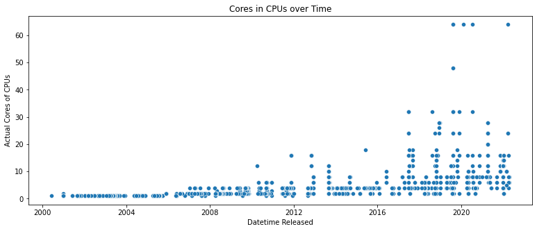

```python
plotcpus(2000,2022,'scatter','datetime_Released','Actual Cores')
plt.xlabel("Datetime Released")
plt.ylabel("Actual Cores of CPUs")
plt.title("Cores in CPUs over Time")
```

The number of cores in CPUS stayed relatively low until 2008, when the first advancements were made in increasing the amount. Towards the early 2010's, a lot more CPUs were released that had more than the standard number of 4 cores, but they were probably not for consumer use at the time. Once we get to 2013, the number of cores found in consumer-friendly processors raised to around 8 and we can also observe that once we go to 2018, the number of cores in higher end processors sky rocketed, even reaching over 60 by 2019.

## Performance Over Time and Moore's Law

```python
from sklearn import linear_model
```

```python
cpu_df=cpu_df.sort_values(by=['Year_Released'])
x=cpu_df['Year_Released']
y=cpu_df['Performance']
ln_Y = np.log(y)
```

```python
model = linear_model.LinearRegression()
X = x.to_numpy().reshape(-1,1)
model.fit(X,ln_Y)
fit=model.predict(X)
fit=np.sort(fit)
```

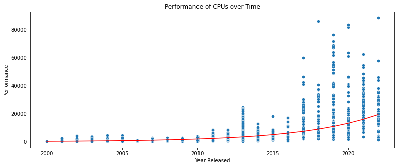

```python
plt.subplots(figsize=(13,5))
sns.scatterplot(x='Year_Released',y='Performance',data=cpu_df)
plt.plot(X,np.exp(fit),color='red')
plt.title("Performance of CPUs over Time")
plt.xlabel("Year Released")
```

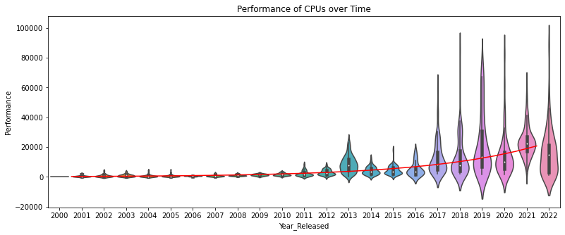

```python
fig=plt.figure(figsize=(13,5))
ax=fig.add_subplot(111, label="1")
ax2=fig.add_subplot(111, label="2", frame_on=False)
sns.violinplot(x='Year_Released',y='Performance',data=cpu_df,ax=ax,scale='width')
ax2.plot(X,np.exp(fit),color='red')
ax2.yaxis.tick_right()
ax2.set_yticks([-19000,100000])
ax2.set_xticks([])
ax2.axes.yaxis.set_visible(False)
ax2.axes.xaxis.set_visible(False)
plt.title("Performance of CPUs over Time")
```

The violin plot gives us a much better representation of the increase in processing performance over time than a scatterplot. The body of the violin plots helps us see how many of the processors were really affected by advancements in increased transistors/cores and if these advancements were brought to a consumer level. For example, though the peak of the plot in 2013 was much higher than any previous year, those achievements were not widespread until 2019 when a bulk of the processors on the market could achieve the same performance. We can also see that our exponential regression model closely fits our data as the regression line hits the center or near the center of every violin plot.

## Our Exponential Regression Function

```python
fit = np.polyfit(cpu_df['Year_Released'], np.log(cpu_df['Performance']), 1)
print(fit)
```

```
[ 1.92997403e-01 -3.80373789e+02]
```

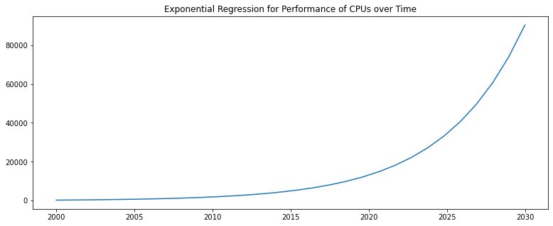

```python
fig=plt.figure(figsize=(13,5))
x = np.linspace(2000,2030,30)
y=np.exp(1.92997403e-01*x -3.80373789e+02)
plt.plot(x,y)
plt.title('Exponential Regression for Performance of CPUs over Time')
```

We now look at the actual function representation of the growth of CPU performance over time using our data. We used the polyfit function while using the log function on the y-values, the performance numbers, to get the accurate coefficients for our exponential regression. We now need to use some simple algebra to take Euler's number and raise it to the coeffcients. With this we get our exponential regression function which is estmiated to be closely related to the y=1.2^x function. This doesn't exactly match Moore's law function of doubling every two years, but it still has the exponetial performance growth that we want and expect to see. We can also now somewhat accurately predict how CPU performance is going to be in the near future with this function. CPU performance is going to be around 80000 when nearing 2030.

```python
value=[]
for i,row in cpu_df.iterrows():
    value.append(row['Performance']/float(row['Price']))
cpu_df['Price to Performance']=value
```

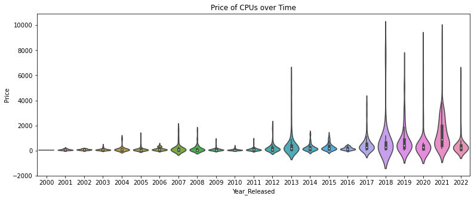

```python
plt.subplots(figsize=(13,5))
sns.violinplot(x='Year_Released',y='Price',data=cpu_df,scale='width')
plt.title('Price of CPUs over Time')
```

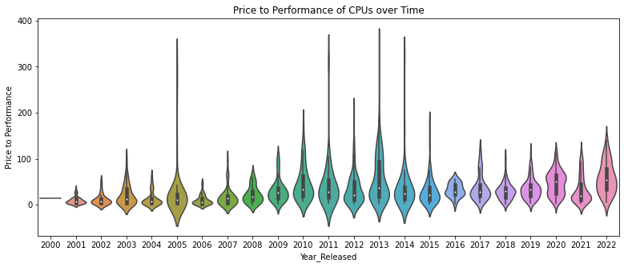

```python
plt.subplots(figsize=(13,5))
sns.violinplot(x='Year_Released',y='Price to Performance',data=cpu_df,scale='width')
plt.title('Price to Performance of CPUs over Time')
```

Though the price of CPUs has been stagnant for the past two decades, the price to performance seems to be slightly increasing. This is beneficial for consumers overall, as the rate of processing power in CPUs has been increasing exponentially as we saw in our previous graph while the cost of manufacturing the computing power is improving as well.

## A Look At How Market Competition Affects the Performance of New CPUs

```python
def getmarketshare(desktop):
    url = 'https://www.cpubenchmark.net/market_share.html'
    response = requests.get(url)
    soup = BeautifulSoup(response.text,'lxml')
    if desktop:
        script_tag = soup.findAll('script')[15]
    else:
        script_tag = soup.findAll('script')[14]
    data=str(script_tag)
    pattern = re.compile(r'([\d+,[\d+|.]+\])')
    records = pattern.findall(data)

    intelshare=[]
    amdshare=[]
    index=0
    for i in records:
        match = re.search(r'\[(\d+),([\d+|.]+)\]',i)
        if index < 74:
            intelshare.append(float(match.group(2)))
        else:
            amdshare.append(float(match.group(2)))
        index+=1
    return intelshare,amdshare
```

```python
def plotmarketshare(intel,amd):
    years=[]
    ticks=[]
    years=np.linspace(2004,2022,74)
    fig, ax_left = plt.subplots(figsize=(15,8))
    ax_right = ax_left.twinx()
    plt.locator_params(axis='x', nbins=20)
    ax_left.plot(years,intel)
    ax_left.plot(years,amd,color='red')
    ax.set_ylabel('Market Share %')
    ax.set_xlabel('Year')
    return ax_left, ax_right
```

Intel was dominating the CPU marketspace for decades, leaving AMD in the dust in terms of marketshare. With essentially no threatening competition, Intel wasn't pushed to create CPUS to outperform someone else. However, in 2017, AMD release a new line of "Ryzen" chips which outperformed many of Intels current chips. This reignition of competition lead to a new CPU war in which the performance of CPUs was drastically affected.

Below, we will use market share data over the years and compare it to the changes in processing power from our calculations above and see how this competition benefit advancements in CPUs as a whole.

Source for marketshare data: https://www.cpubenchmark.net/market_share.html

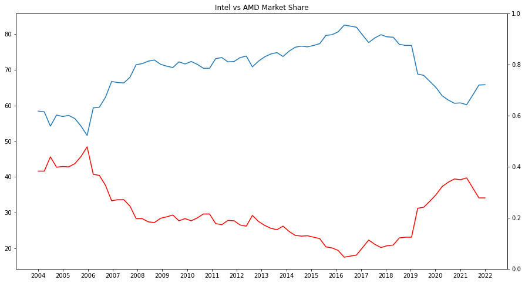

```python
intelshare,amdshare=getmarketshare(False)
plotmarketshare(intelshare,amdshare)
plt.title('Intel vs AMD Market Share')
```

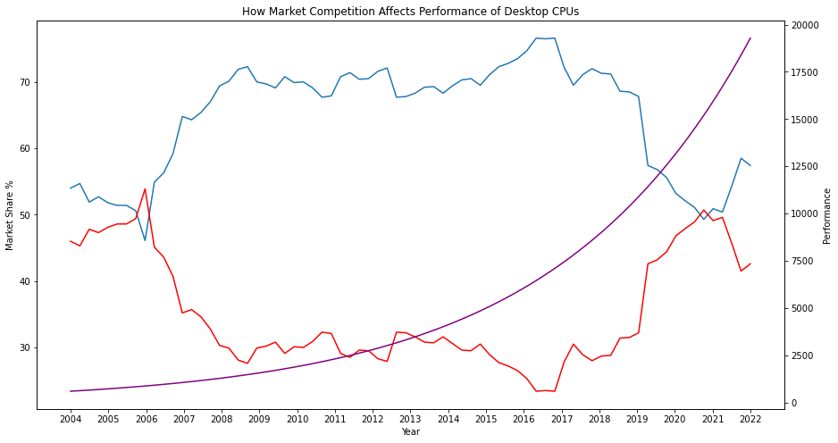

```python
x = np.linspace(2004,2022,100)
y=np.exp(1.92997403e-01*x -3.80373789e+02)
intelshare,amdshare=getmarketshare(True)
ax_left,ax_right=plotmarketshare(intelshare,amdshare)
ax_right.plot(x,y,color='purple')
plt.title("How Market Competition Affects Performance of Desktop CPUs")
ax_left.set_xlabel('Year')
ax_left.set_ylabel('Market Share %')
ax_right.set_ylabel('Performance')
```

In the desktop CPU scene, AMD's introduction of Ryzen series cards has had a massive increase in their desktop marketshare. AMD leveled the marketshare by 2021, falling in 2022 due to production issues and chip shortages.

# Hypothesis Testing

```python
import statsmodels.api as sm
from scipy import stats
```

Now we want to test our hypothesis to see if CPU performance actually coincides with Moore's law. The null hypothesis for our test is that CPU performance does not grow exponentially over time. We will be using our model and the statsmodels package to calculate our p-value and the coefficient of determination, R^2. To reject our null hypothesis, we are looking for a p-value of less than 0.05. We are also going to look for a R^2 value as it tells us how well our model fits the data. The closer the R^2 value is to 1 the better our model fits the data.

```python
X2 = sm.add_constant(X)
est = sm.OLS(ln_Y, X2)
est2 = est.fit()
print(est2.summary())
```

```
                            OLS Regression Results
==============================================================================
Dep. Variable:            Performance   R-squared:                       0.669
Model:                            OLS   Adj. R-squared:                  0.668
Method:                 Least Squares   F-statistic:                     3088.
Date:                Mon, 16 May 2022   Prob (F-statistic):               0.00
Time:                        17:37:20   Log-Likelihood:                -1905.3
No. Observations:                1532   AIC:                             3815.
Df Residuals:                    1530   BIC:                             3825.
Df Model:                           1
Covariance Type:            nonrobust
==============================================================================
                 coef    std err          t      P>|t|      [0.025      0.975]
------------------------------------------------------------------------------
const       -380.3738      6.990    -54.415      0.000    -394.085    -366.662
x1             0.1930      0.003     55.572      0.000       0.186       0.200
==============================================================================
Omnibus:                        0.321   Durbin-Watson:                   0.934
Prob(Omnibus):                  0.852   Jarque-Bera (JB):                0.363
Skew:                           0.033   Prob(JB):                        0.834
Kurtosis:                       2.962   Cond. No.                     6.56e+05
==============================================================================

Notes:
[1] Standard Errors assume that the covariance matrix of the errors is correctly specified.
[2] The condition number is large, 6.56e+05. This might indicate that there are
strong multicollinearity or other numerical problems.
```

As seen from the results, we have a p-value of less than 0.05. We actually got a p-value of 0.0, so we can confidently reject the null hypothesis of processor performance not growing exponentially over time.

Now taking a look at the R^2 value, we see it has a value of 0.669. Having a high R^2 model means that the model fits your data. The closer to 1 it is the better your model. Our model isn't exactly close to 1. This is supported by the fact that we got a function for performance over time of y=1.2^x earlier. This is most likely due to the high variance of CPU performance when AMD started releasing their Ryzen CPUs around 2017. During this time we see a huge jump in performance across the board. This made our model inaccurate because it did most of its values came from 2000 to 2016 where CPU performance wasn't increasing that much.

```python
residuals = []
for i,row in cpu_df.iterrows():
    residuals.append(row['Performance']-model.predict([[(row['Year_Released'])]])[0])
cpu_df['Residual']=residuals
```

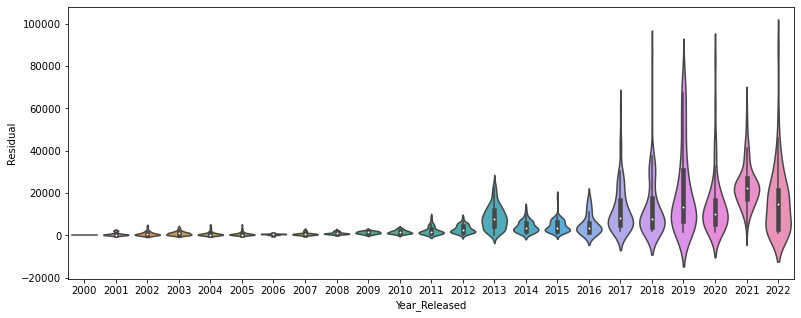

```python
plt.figure(figsize=(13,5))
sns.violinplot(x='Year_Released',y='Residual',data=cpu_df,scale='width')
```

After plotting the residuals of the actual performance minus the predicted value from our model, we can see that the residuals start to vary highly as time goes on. This is mostly due to the drastic performance increase due to competition between AMD and Intel and due to AMD's Ryzen CPUs release. To lower our residuals we would want to weigh the values from 2017 onwards more in our model so that it can have more accurate predicted performance numbers.

# The Takeaway

After analyzing the CPU performance and cost over time we have learned quite a few things. The most important thing we have seen is that the performance of CPUs does have a somewhat exponetial growth that is closely related to Moore's Law. Although it doesn't exactly match Moores Law of doubling performance every two years(a function that is similar to y=2^x), we do get a closely matched function of y=1.2^x. Moore's law also states that the cost of compute power should be halved. From our analysis, we see that the cost and the cost to performance of processors have been relatively the same throughout time. This heavily is due to things such as inflation, but just by looking at the numbers this part of Moore's law doesn't seem to coincide with reality. Lastly, we have found that market competition, mainly between AMD and Intel, has a huge impact on the increase in performance for processors. As seen from our analysis, the increase in performance of processors saw exponential growth after AMD came out with their new Ryzen series processors that was made to combat Intel who has controlled most of the CPU market during the past decade.

Market competition is important for technological advancements, so we hope to see more of that to get more powerful and more efficient processors in the future.

# Improvements

The main thing we would want to improve upon is our exponetial regression function to get it closer to a funciton that is doubling every two years(similar to y=2^x). The improvements we would make to our model would be to put more weight on the performance values starting from 2017 because that is when we actually start to see exponetial growth in performance for processors.